# SA Phage Rotation Project

Sophia Aredas

16 October, 2023

11:39

```r
# Efficiently load packages
pacman::p_load(readr, stringr, tidyr, tidyverse, dplyr, ggplot2, tidytext, scales, wesanderson, ggpubr, wacolors, rcartocolor, install = FALSE)
```

### Load summary files produced by geNomad

```r
#set working directory
setwd("/local/workdir/sna49/SA_Fall2023_Phage_Rotation/Data/4_concatenated_files/")

#1. looking at plasmid genes
setwd("/local/workdir/sna49/SA_Fall2023_Phage_Rotation/Data/4_concatenated_files/")
plasmid_genes <- read.table(file = "plasmid_genes.tsv", sep ="\t", header = TRUE)

#2. looking at plasmid summary
setwd("/local/workdir/sna49/SA_Fall2023_Phage_Rotation/Data/4_concatenated_files/")
plasmid_summary <- read.table(file = "plasmid_summary.tsv", sep ="\t", header = TRUE)

#3 looking at virus genes
setwd("/local/workdir/sna49/SA_Fall2023_Phage_Rotation/Data/4_concatenated_files/")
virus_genes <- read.table(file = "virus_genes.tsv", sep ="\t", header = TRUE)

#4 looking at virus summary
setwd("/local/workdir/sna49/SA_Fall2023_Phage_Rotation/Data/4_concatenated_files/")
virus_summary <- read.table(file = "virus_summary.tsv", sep ="\t", header = TRUE)
```

## Creating data frames so that we can analyze the geNomad outputs

### Creating dataframe of plasmid genes

```r
#1. plasmid genes
#need to create dataframe
df_plasmidgenes <- data.frame(plasmid_genes)

#split the first column called gene into multiple columns
#because there is so much going on with the column name we are going to separate each word into its own column and then mutate it together (dont be alarmed)
df_plasmidgenes <- df_plasmidgenes %>% separate(gene, c('Seq_Name', 'DASTool', 'Bin', 'fa_info', 'plasmid', 'genes', 'tsv', 'Contig', 'bp_length', 'Contig_Number'))

#now we are going to mutate the combine the columns together
df_plasmidgenes$Seq_Name <- paste(df_plasmidgenes$Seq_Name, df_plasmidgenes$DASTool, df_plasmidgenes$Bin, sep = "_")
df_plasmidgenes$fa_info <- paste(df_plasmidgenes$fa_info, df_plasmidgenes$plasmid, df_plasmidgenes$genes, df_plasmidgenes$tsv, sep = "_")
df_plasmidgenes$Contig <- paste(df_plasmidgenes$Contig, df_plasmidgenes$bp_length, sep = "_")


#then we need to get rid of the extra columns that we do not need
df_plasmidgenes <- subset(df_plasmidgenes, select = -c(DASTool, plasmid, genes, tsv, bp_length)) #invalid argument need to fix

#view to make sure it looks good
```

### Creating dataframe of plasmid summary

```r
#2. plasmid summary
#need to create dataframe
df_plasmidsum <- data.frame(plasmid_summary)

#split the first column called gene into multiple columns
df_plasmidsum <- df_plasmidsum %>% separate(seq_name, c('Seq_Name', 'DASTool', 'Bin', 'fa_info', 'plasmid', 'genes', 'tsv', 'Contig', 'bp_length'))

#now we are going to mutate the combine the columns together
df_plasmidsum$Seq_Name <- paste(df_plasmidsum$Seq_Name, df_plasmidsum$DASTool, df_plasmidsum$Bin, sep = "_")
df_plasmidsum$fa_info <- paste(df_plasmidsum$fa_info, df_plasmidsum$plasmid, df_plasmidsum$genes, df_plasmidsum$tsv, sep = "_")
df_plasmidsum$Contig <- paste(df_plasmidsum$Contig, df_plasmidsum$bp_length, sep = "_")

#then we need to get rid of the extra columns that we do not need
df_plasmidsum <- subset(df_plasmidsum, select = -c(DASTool, plasmid, genes, tsv, bp_length))

#view to make sure it looks good
```

### Creating virus genes dataframe

```r
#3. virus genes
#need to create dataframe
df_virusgenes <- data.frame(virus_genes)

#split the first column called gene into multiple columns
df_virusgenes <- df_virusgenes %>% separate(gene, c('Seq_Name', 'DASTool', 'Bin', 'fa_info', 'virus', 'genes', 'tsv', 'Contig', 'bp_length', 'Contig_Number'))

#now we are going to mutate the combine the columns together
df_virusgenes$Seq_Name <- paste(df_virusgenes$Seq_Name, df_virusgenes$DASTool, df_virusgenes$Bin, sep = "_")
df_virusgenes$fa_info <- paste(df_virusgenes$fa_info, df_virusgenes$virus, df_virusgenes$genes, df_virusgenes$tsv, sep = "_")
df_virusgenes$Contig <- paste(df_virusgenes$Contig, df_virusgenes$bp_length, sep = "_")

#then we need to get rid of the extra columns that we do not need
df_virusgenes <- subset(df_virusgenes, select = -c(DASTool, virus, genes, tsv, bp_length)) #invalid argument need to fix

#view to make sure it looks good
```

### Creating virus summary dataframe

```r
#4. virus summary
#need to create dataframe
df_virussum <- data.frame(virus_summary)

#split the first column called gene into multiple columns
df_virussum <- df_virussum %>% separate(seq_name, c('Seq_Name', 'DASTool', 'Bin', 'fa_info', 'virus', 'genes', 'tsv', 'Contig', 'bp_length'))

#now we are going to mutate the combine the columns together
df_virussum$Seq_Name <- paste(df_virussum$Seq_Name, df_virussum$DASTool, df_virussum$Bin, sep = "_")
df_virussum$fa_info <- paste(df_virussum$fa_info, df_virussum$virus, df_virussum$genes, df_virussum$tsv, sep = "_")
df_virussum$Contig <- paste(df_virussum$Contig, df_virussum$bp_length, sep = "_")

#then we need to get rid of the extra columns that we do not need
df_virussum <- subset(df_virussum, select = -c(DASTool, virus, genes, tsv, bp_length))

#view to make sure it looks good
```

## Combining Gus’s data frame and mine together to map the bin to the fraction class

### The names on the 346 MAG files are from the filtration steps. The free coassembly was done from the free filtration, particle coassembly was done from the particle, and DASTools was presumably done from the whole filtration

```r
#but the names on each of the files are meaningless. The file could be like free-coassembly bin 90 but we do not know if they are actually FL, PA, or generalists.
#Thanks to Gus he provided MAG_Growth_Fraction.RData which there were calculations to see if bins prefer to be FL, PA, or Generalists. I will be adding his column into my dataset so that way I am able to compare between bacterial lifestyles

#load in the MAG_Growth_Fraction.RData to your environment
load("/local/workdir/sna49/SA_Fall2023_Phage_Rotation/Data/MAG_Growth_and_Fraction.RData")

#gsub so that free and particle coassemblies match
mag_full_df$bin <- gsub("-", "_", mag_full_df$bin)

#join columns together with merge left_join
merge_virussum_magfull <- left_join(df_virussum, mag_full_df, by = c("Seq_Name" = "bin"))
merge_plasmidgenes_magfull <- left_join(df_plasmidgenes, mag_full_df, by = c("Seq_Name" = "bin"))
merge_virusgenes_magfull <- left_join(df_virusgenes, mag_full_df, by = c("Seq_Name" = "bin"))
merge_plasmidsum_magfull <- left_join(df_plasmidsum, mag_full_df, by = c("Seq_Name" = "bin"))
```

## Time to visualize

### Plasmid Analysis

#### Relative Abundance of Fraction Class

##### Bar Graph with no percentages just the relative abundance count

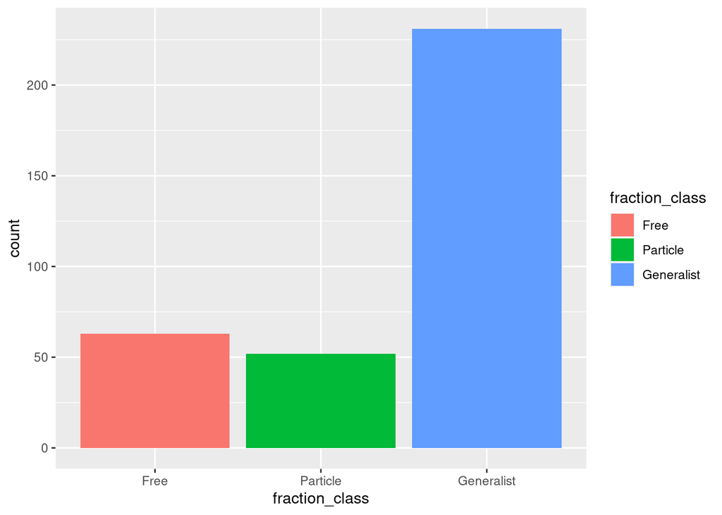

```r
#i am making a summary df to calculate the sum of fraction_class
#looking at Gus's MAG_full_df
#this is the bargraph version with no percentages
count_magfull <- mag_full_df %>%
  group_by(fraction_class) %>%
  summarise(count = n(), .groups = "drop")

count_fraction_class <- count_magfull %>%
  ggplot(aes(x = fraction_class, y = count, fill = fraction_class))+
  geom_bar(stat = "identity", position = "dodge")

count_fraction_class
```

##### Bar Graph with percentages

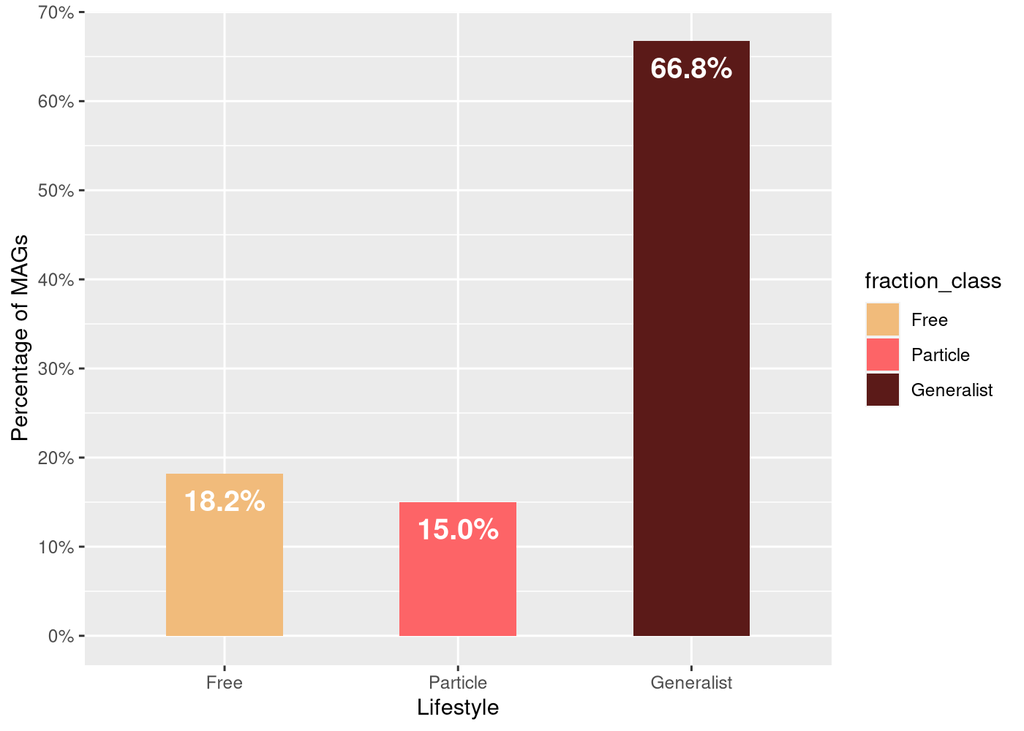

```r
#this is the percentage bar graph version
percent_mag_full <- mag_full_df %>%
  group_by(fraction_class) %>%
  summarise(count = n()) %>%
  mutate(percent = count/sum(count))


# ggplot(percent_mag_full, aes(x = fraction_class, y = percent, fill = fraction_class, label = scales::percent(percent(stat(count))))) +
#   geom_bar(stat = "identity") +
#   geom_text(stat = "identity",
#             position = position_dodge(.9),
#             vjust = -0.5,
#             size = 3) +
#   labs(x = "Lifestyle", y = "Percent", fill = "Fraction Class") +
#   theme_minimal(base_size = 14)
#
# percent <- ggplot(percent_mag_full, aes(x = fraction_class, y = percent, fill = fraction_class))+
#   geom_bar(stat = "identity", position = "dodge")
#
# percent +
#   scale_y_continuous(labels = scales::percent,
#                      breaks= scales::pretty_breaks(n = 7))

#then all together
percent <- ggplot(percent_mag_full, aes(x = fraction_class, y = percent, fill = fraction_class, label = scales::percent(percent)))+
  geom_col(width = 0.5)+
  labs(x = "Lifestyle",
       y = "Percentage of MAGs")+
  scale_y_continuous(labels = scales::percent,
                     breaks= scales::pretty_breaks(n = 7))+
  geom_text(nudge_y = -.03,
            color = "white",
            size = 5,
            fontface = "bold")+
 # scale_fill_carto_d(palette = , directino = -1)
  scale_fill_manual(values=wes_palette(n=3, name="GrandBudapest1"))
  #scale_fill_brewer(palette = "Dark2")
percent
```

```r
#percent + labs(fill = "Lifestyle")

#009392,#39b185,#9ccb86,#e9e29c,#eeb479,#e88471,#cf597e# A tibble: 3 × 2
 # fraction_class count
 # <fct>          <int>
#1 Free              63
#2 Particle          52
#3 Generalist       231
```

##### Visualize the number of plasmid encoded genes and fraction class

###### This is the number of plasmid encoded genes / MAG represented in bar graph form

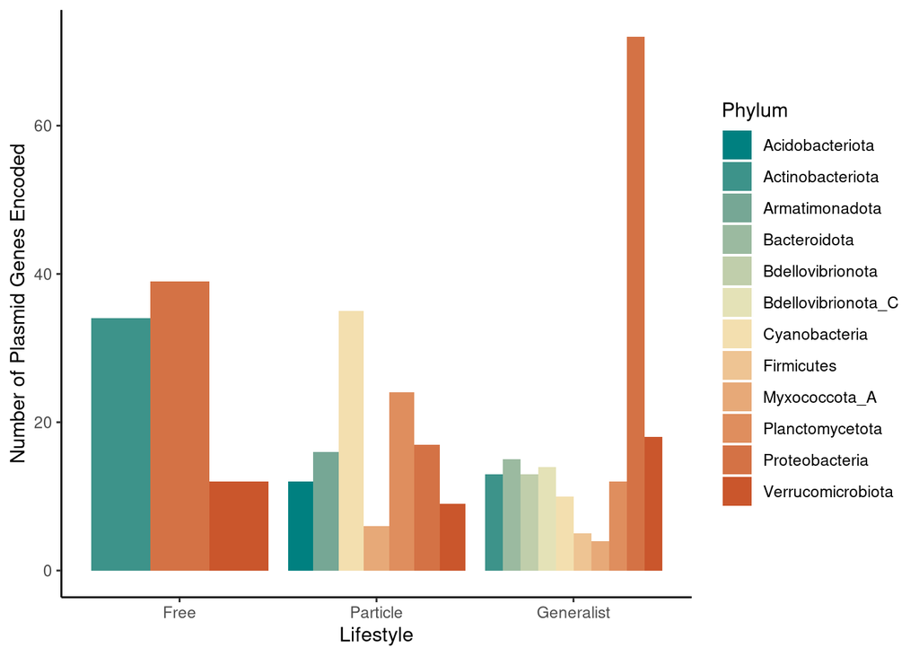

```r
#barplot to visualize (from the plasmid summary file) to see from which bacterial lifestyle has more or less encoding genes
#n_genes just refers to the number of genes encoded by the sequence but does not have to necessarily number of plasmid genes
#n_genes also looks at the number of genes encoded by each contig within the bin so there are lots of instances in which there are multiple plasmid hits from a bin thats why the number does not exactly equal 346
number_of_genes <- ggplot(merge_plasmidsum_magfull, aes(x = fraction_class, y = n_genes, fill = Phylum))+
  geom_bar(position = "dodge", stat = "identity") +
  scale_fill_carto_d(palette = "Geyser")+
  xlab("Lifestyle")+
  ylab("Number of Plasmid Genes Encoded")+
  theme_classic()

number_of_genes
```

```r
#looking at the number of peg divided by mag but represented in a bar graph form
#count all the genes in the bin
peg <- merge_plasmidsum_magfull
total_PEG_bin <- peg %>%
  group_by(Seq_Name, Bin, n_genes, fraction_class, Phylum) %>%
  summarise(
    Count_Genes = n(),
    .groups = "drop",
    total_n_genes = sum(n_genes))


#now count the number of seq_names
count_peg_seq <- total_PEG_bin %>%
  group_by(Seq_Name) %>%
  mutate(Count_Seq_name = n())

count_peg_seq
```

```
## # A tibble: 760 × 8
## # Groups:   Seq_Name [226]
##    Seq_Name             Bin    n_genes fraction_class Phylum          Count_Genes total_n_genes Count_Seq_name
##    <chr>                <chr>    <int> <fct>          <chr>                 <int>         <int>          <int>
##  1 91614_DAStool_bin128 bin128       3 Generalist     Planctomycetota           1             3              2
##  2 91614_DAStool_bin128 bin128       4 Generalist     Planctomycetota           1             4              2
##  3 91614_DAStool_bin130 bin130       4 Generalist     Proteobacteria            1             4              7
##  4 91614_DAStool_bin130 bin130       6 Generalist     Proteobacteria            1             6              7
##  5 91614_DAStool_bin130 bin130       7 Generalist     Proteobacteria            1             7              7
##  6 91614_DAStool_bin130 bin130      13 Generalist     Proteobacteria            1            13              7
##  7 91614_DAStool_bin130 bin130      23 Generalist     Proteobacteria            1            23              7
##  8 91614_DAStool_bin130 bin130      30 Generalist     Proteobacteria            1            30              7
##  9 91614_DAStool_bin130 bin130      56 Generalist     Proteobacteria            1            56              7
## 10 91614_DAStool_bin135 bin135       4 Generalist     Cyanobacteria             1             4              3
## # ℹ 750 more rows
```

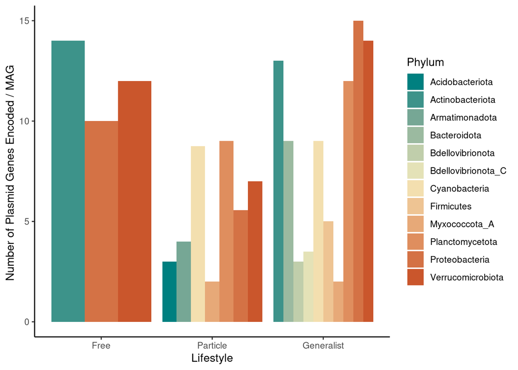

```r
#now we are going to divide by the conjugation gene type by the bin
count_peg_seq$genes_per_bin <- count_peg_seq$total_n_genes / count_peg_seq$Count_Seq_name

peg_phy <- ggplot(count_peg_seq, aes(x = fraction_class, y = genes_per_bin, fill = Phylum))+
  geom_bar(position = "dodge", stat = "identity") +
  scale_fill_carto_d(palette = "Geyser")+
  xlab("Lifestyle")+
  ylab("Number of Plasmid Genes Encoded / MAG ")+
  theme_classic()

peg_phy
```

```r
peg_per_bin <- ggplot(count_peg_seq, aes(x = fraction_class, y = genes_per_bin, fill = fraction_class))+
  geom_boxplot(outlier.alpha = 0, alpha = .8)+
  geom_point()+
  #ggtitle("fraction class ~ genes/bin")+
  #scale_fill_carto_d(palette = "Geyser")+
  xlab("Lifestyle")+
  ylab("Number of Plasmid Encoded Genes / MAG")+
  scale_fill_wa_d(palette = "rainier", reverse = TRUE)+
  #scale_fill_brewer(palette = "Dark2")
 # coord_cartesian(ylim = quantile(count_peg_seq$genes_per_bin, c(0.01,0.999)))+
# #  stat_compare_means(label.y = c(1,1,1), tip.length = .01, comparisons = list(
#     c("Free", "Particle"),
#     c("Free", "Generalist"),
#     c("Particle", "Generalist")),
#                      method = "",
#                      label = "p.signif", hide.ns = FALSE)+
  theme_classic()
  #theme(plot.title = element_text(hjust = 0.5))
```

##### Number of plasmid encoded genes represented by a box plot

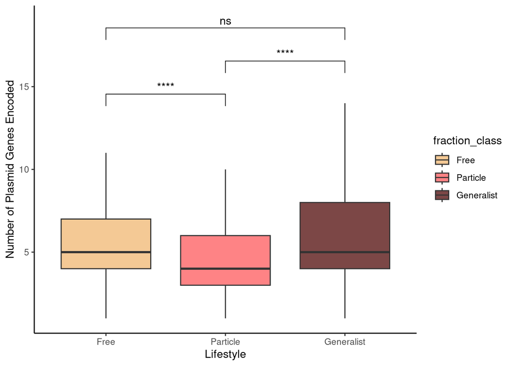

```r
#instead lets look at the number of genes found on plasmids as a box plot instead of bar graph
#relative abundance NOT divided by MAG
number_of_genes <- ggplot(merge_plasmidsum_magfull, aes(x = fraction_class, y = n_genes, fill = fraction_class))+
  geom_boxplot(outlier.alpha = 0, alpha = .8)+
  xlab("Lifestyle")+
  ylab("Number of Plasmid Genes Encoded")+
  scale_fill_manual(values=wes_palette(n=3, name="GrandBudapest1"))+
  coord_cartesian(ylim = quantile(merge_plasmidsum_magfull$n_genes, c(0.01,0.99)))+
  stat_compare_means(label.y = c(11,15,13), tip.length = .01, comparisons = list(
    c("Free", "Particle"),
    c("Free", "Generalist"),
    c("Particle", "Generalist")),
                     method = "wilcox.test", paired = FALSE,
                     label = "p.signif", hide.ns = FALSE)+
  #scale_y_continuous(limits = quantile(merge_plasmidsum_magfull$n_genes, c(0.05,0.95)))+
  theme_classic()

number_of_genes
```

```r
#now lets divide the number of genes by MAG (AKA lest visualize the number of plasmid encoded genes per bin)

#count all the genes in the bin
peg <- merge_plasmidsum_magfull
total_PEG_bin <- peg %>%
  group_by(Seq_Name, Bin, n_genes, fraction_class, Phylum) %>%
  summarise(
    Count_Genes = n(),
    .groups = "drop",
    total_n_genes = sum(n_genes))


#now count the number of seq_names
count_peg_seq <- total_PEG_bin %>%
  group_by(Seq_Name) %>%
  mutate(Count_Seq_name = n())

count_peg_seq
```

```
## # A tibble: 760 × 8
## # Groups:   Seq_Name [226]
##    Seq_Name             Bin    n_genes fraction_class Phylum          Count_Genes total_n_genes Count_Seq_name
##    <chr>                <chr>    <int> <fct>          <chr>                 <int>         <int>          <int>
##  1 91614_DAStool_bin128 bin128       3 Generalist     Planctomycetota           1             3              2
##  2 91614_DAStool_bin128 bin128       4 Generalist     Planctomycetota           1             4              2
##  3 91614_DAStool_bin130 bin130       4 Generalist     Proteobacteria            1             4              7
##  4 91614_DAStool_bin130 bin130       6 Generalist     Proteobacteria            1             6              7
##  5 91614_DAStool_bin130 bin130       7 Generalist     Proteobacteria            1             7              7
##  6 91614_DAStool_bin130 bin130      13 Generalist     Proteobacteria            1            13              7
##  7 91614_DAStool_bin130 bin130      23 Generalist     Proteobacteria            1            23              7
##  8 91614_DAStool_bin130 bin130      30 Generalist     Proteobacteria            1            30              7
##  9 91614_DAStool_bin130 bin130      56 Generalist     Proteobacteria            1            56              7
## 10 91614_DAStool_bin135 bin135       4 Generalist     Cyanobacteria             1             4              3
## # ℹ 750 more rows
```

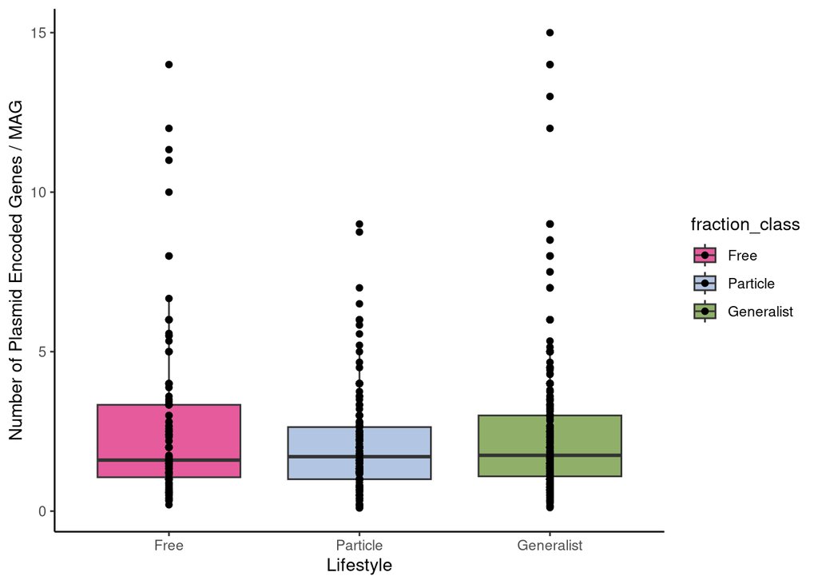

```r
#now we are going to divide by the conjugation gene type by the bin
count_peg_seq$genes_per_bin <- count_peg_seq$total_n_genes / count_peg_seq$Count_Seq_name

#now that we have ourgenes/sequence name we can plot our data to see what is happening
peg_per_bin <- ggplot(count_peg_seq, aes(x = fraction_class, y = genes_per_bin, fill = fraction_class))+
  geom_boxplot(outlier.alpha = 0, alpha = .8)+
  geom_point()+
  #ggtitle("fraction class ~ genes/bin")+
  #scale_fill_carto_d(palette = "Geyser")+
  xlab("Lifestyle")+
  ylab("Number of Plasmid Encoded Genes / MAG")+
  scale_fill_wa_d(palette = "rainier", reverse = TRUE)+
  #scale_fill_brewer(palette = "Dark2")
#coord_cartesian(ylim = quantile(count_peg_seq$genes_per_bin, c(0.001,0.999)))+
#stat_compare_means(label.y = c(5,5,5), tip.length = .01, comparisons = list(
    # c("Free", "Particle"),
    # c("Free", "Generalist"),
    # c("Particle", "Generalist")),
    #                  method = ,
    #                  label = "p.signif", hide.ns = FALSE)+
  theme_classic()
  #theme(plot.title = element_text(hjust = 0.5))
peg_per_bin
```

#### Number of plasmid encoded genes divided by length [not sure how to do this]

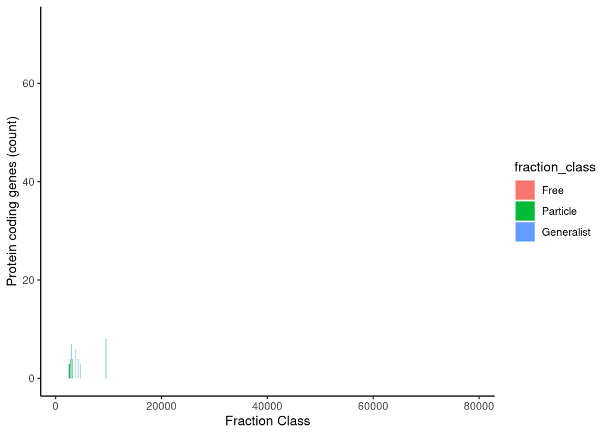

```r
#after talking with Marian it would be interesting to see how the number of genes per contig in the MAG vary according to length. Trying to get at the vibes of length and genome size is correlated with each other
#looking at the merge_plasmid_sum_magfull because it seems that its more finalized in terms of bin and contigs?
merge_plasmidsum_magfull$n_genes_per_length <- merge_plasmidsum_magfull$n_genes / merge_plasmidsum_magfull$length

#but maybe I should do it y=  n_genes/mag x = length
#????????????????
n_genes_length <- ggplot(merge_plasmidsum_magfull, aes(x = length, y = n_genes, fill = fraction_class))+
  geom_bar(position = "dodge", stat = "identity") +
  #scale_x_reordered() +
 # facet_wrap(~fraction_class, scale ="free_x")+
  xlab("Fraction Class")+
  ylab("Protein coding genes (count)")+
  theme_classic()

n_genes_length
```

```r
#??????????????
```

#### Density plot looking at number of plasmid encoded genes/MAG (x axis) and the density (y axis)

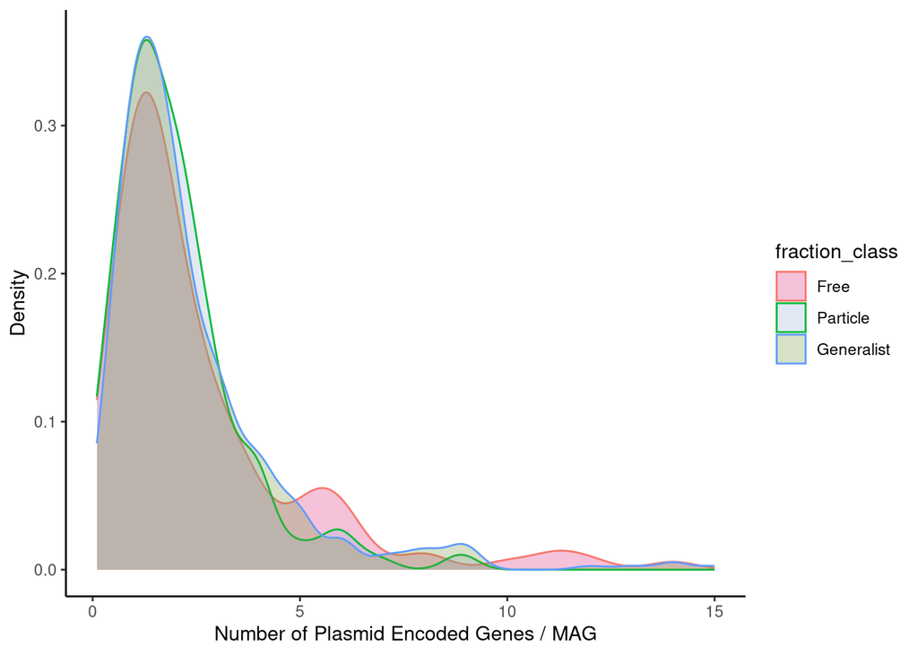

```r
peg_density <- ggplot(count_peg_seq, aes(x = genes_per_bin, color = fraction_class, fill = fraction_class))+
  geom_density(alpha = 0.3)+
  xlab("Number of Plasmid Encoded Genes / MAG")+
  ylab("Density")+
  scale_fill_wa_d(palette = "rainier", reverse = TRUE)+
  theme_classic()

peg_density
```

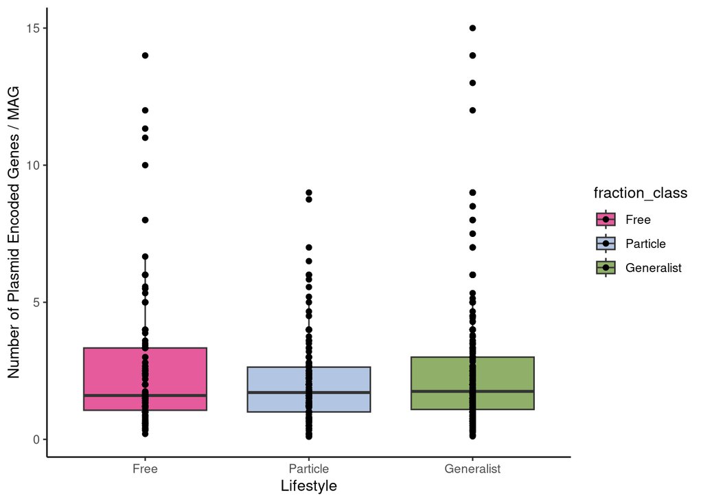

```r
peg_per_bin <- ggplot(count_peg_seq, aes(x = fraction_class, y = genes_per_bin, fill = fraction_class))+
  geom_boxplot(outlier.alpha = 0, alpha = .8)+
  geom_point()+
  #ggtitle("fraction class ~ genes/bin")+
  #scale_fill_carto_d(palette = "Geyser")+
  xlab("Lifestyle")+
  ylab("Number of Plasmid Encoded Genes / MAG")+
  scale_fill_wa_d(palette = "rainier", reverse = TRUE)+
  #scale_fill_brewer(palette = "Dark2")
#coord_cartesian(ylim = quantile(count_peg_seq$genes_per_bin, c(0.001,0.999)))+
#stat_compare_means(label.y = c(5,5,5), tip.length = .01, comparisons = list(
    # c("Free", "Particle"),
    # c("Free", "Generalist"),
    # c("Particle", "Generalist")),
    #                  method = ,
    #                  label = "p.signif", hide.ns = FALSE)+
  theme_classic()
  #theme(plot.title = element_text(hjust = 0.5))
peg_per_bin
```

#### Visualizing the number of conjugation genes

##### This is just looking at the relative abundance between the 3 lifestyles

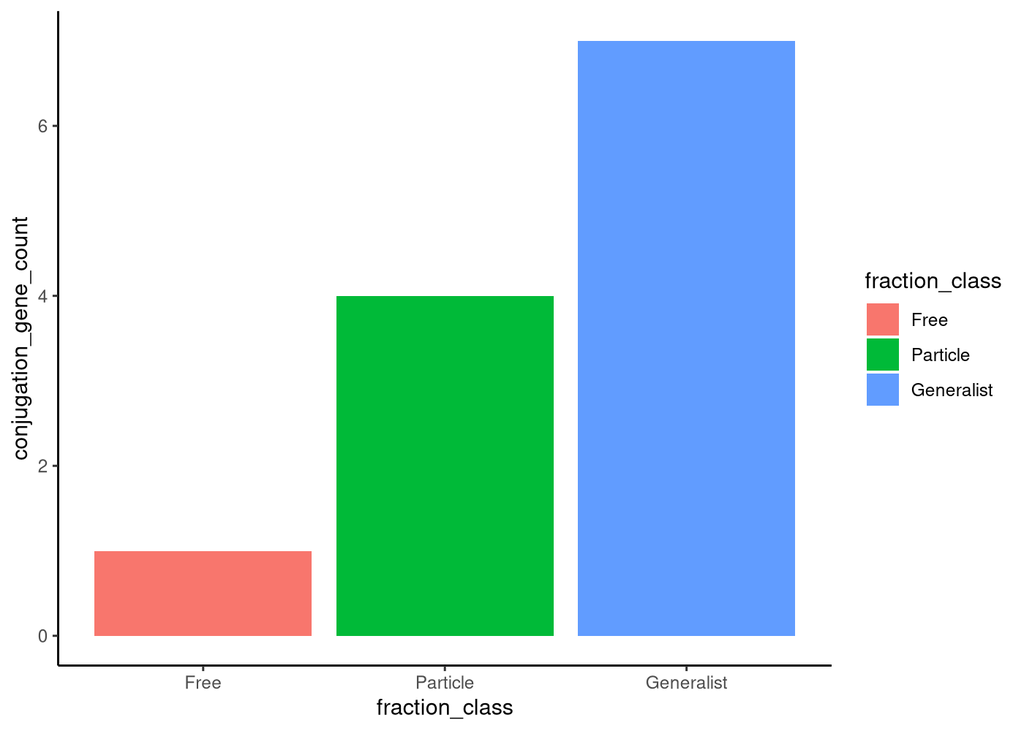

```r
#now we will visualize the amount of conjugation genes within the merge_plasmidsum dataframe
congenee <- merge_plasmidsum_magfull
#the name congenee just reminds me of the chinese dish congee so the name is really meaningless haha but i am also hungry

congenee <- congenee %>%
  filter(!is.na(conjugation_genes)) %>%
  mutate(conjugation_gene_count = str_count(conjugation_genes, ";") +1)
# congenee #you will notice that a new column is added that includes the conjugation_gene_count with its count and omits the <NA>
#
# #we can look at the distribution of conjugation genes found looking at fraction_class and seeing the different phyla represented
congene_gg_phy <- ggplot(congenee, aes(x = fraction_class, y = conjugation_gene_count, fill = Phylum))+
  geom_bar(position = "dodge", stat = "identity") +
  theme_classic()
#
# congene_gg_phy #interesting that proteobacteria is represented in all fractions
#
congene_gg <- ggplot(congenee, aes(x = fraction_class, y = conjugation_gene_count, fill = fraction_class))+
  geom_bar(position = "dodge", stat = "identity") +
  theme_classic()

congene_gg
```

```r
# total_conj_gene_per_bin <- congenee %>%
#   group_by(Seq_Name, Bin, conj_gene_type, fraction_class) %>%
#   summarise(Count_Genes = n(), .groups = "drop")
#
#
# #now count the number of seq_names
# #remember that we are taking into consideration the kind of conjugation gene in this
# count_seq_name <- total_conj_gene_per_bin %>%
#   group_by(Seq_Name) %>%
#   mutate(Count_Seq_name = n())
#
# count_seq_name
# #now we are going to divide by the conjugation gene type by the bin
# count_seq_name$genes_per_bin <- count_seq_name$Count_Genes / count_seq_name$Count_Seq_namec
```

#### Visualizing conjugation genes divided by MAG

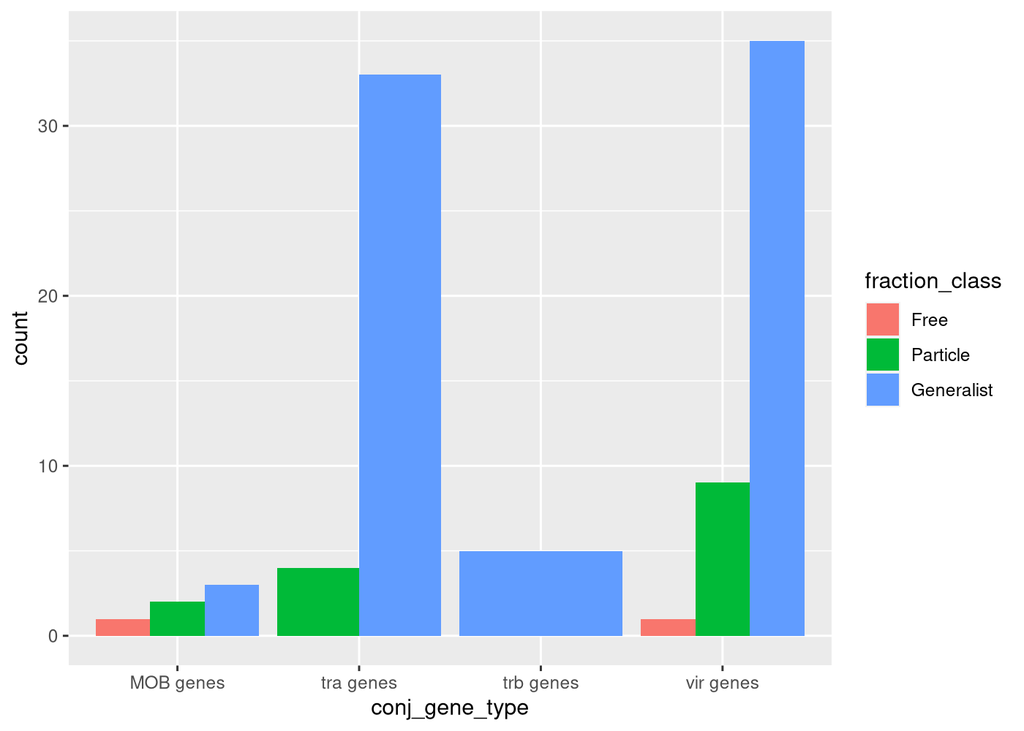

```r
congenee <- merge_plasmidgenes_magfull
congenee <- congenee %>%
  filter(!is.na(annotation_conjscan)) %>%
  mutate(conj_gene_type = case_when(grepl("trb", annotation_conjscan) ~ "trb genes",
                                    grepl("vir", annotation_conjscan) ~ "vir genes",
                                    grepl("MOB", annotation_conjscan) ~ "MOB genes",
                                    grepl("tra", annotation_conjscan) ~ "tra genes",
                                    grepl("t4cp1", annotation_conjscan) ~ "tra genes")) %>%
  select(Seq_Name, Bin, annotation_conjscan, conj_gene_type, fraction_class)

congenee_gg <- ggplot(congenee, aes(x = conj_gene_type, fill = fraction_class))+
  geom_bar(stat = "count", position = "dodge")
congenee_gg
```

```r
table(congenee$conj_gene_type, congenee$fraction_class)
```

```
##
##             Free Particle Generalist
##   MOB genes    1        2          3
##   tra genes    0        4         33
##   trb genes    0        0          5
##   vir genes    1        9         35
```

```r
  #            Free  Particle  Generalist
  # MOB genes    1        2          3
  # tra genes    0        4         33
  # trb genes    0        0          5
  # vir genes    1        9         35

#
# #now we can visualize the number of conjugation genes per bin
# #count all the genes in the bin by the conj_gene_type
total_conj_gene_per_bin <- congenee %>%
  group_by(Seq_Name, Bin, conj_gene_type, fraction_class) %>%
  summarise(Count_Genes = n(), .groups = "drop")


#now count the number of seq_names
#remember that we are taking into consideration the kind of conjugation gene in this
count_seq_name <- total_conj_gene_per_bin %>%
  group_by(Seq_Name) %>%
  mutate(Count_Seq_name = n())

count_seq_name
```

```
## # A tibble: 35 × 6
## # Groups:   Seq_Name [20]
##    Seq_Name             Bin    conj_gene_type fraction_class Count_Genes Count_Seq_name
##    <chr>                <chr>  <chr>          <fct>                <int>          <int>
##  1 91614_DAStool_bin138 bin138 vir genes      Generalist               2              1
##  2 91618_DAStool_bin29  bin29  tra genes      Generalist              10              3
##  3 91618_DAStool_bin29  bin29  trb genes      Generalist               1              3
##  4 91618_DAStool_bin29  bin29  vir genes      Generalist               1              3
##  5 91619_DAStool_bin170 bin170 trb genes      Generalist               1              2
##  6 91619_DAStool_bin170 bin170 vir genes      Generalist               1              2
##  7 91623_DAStool_bin100 bin100 vir genes      Free                     1              1
##  8 91629_DAStool_bin130 bin130 MOB genes      Free                     1              1
##  9 91629_DAStool_bin131 bin131 MOB genes      Generalist               1              4
## 10 91629_DAStool_bin131 bin131 tra genes      Generalist               5              4
## # ℹ 25 more rows
```

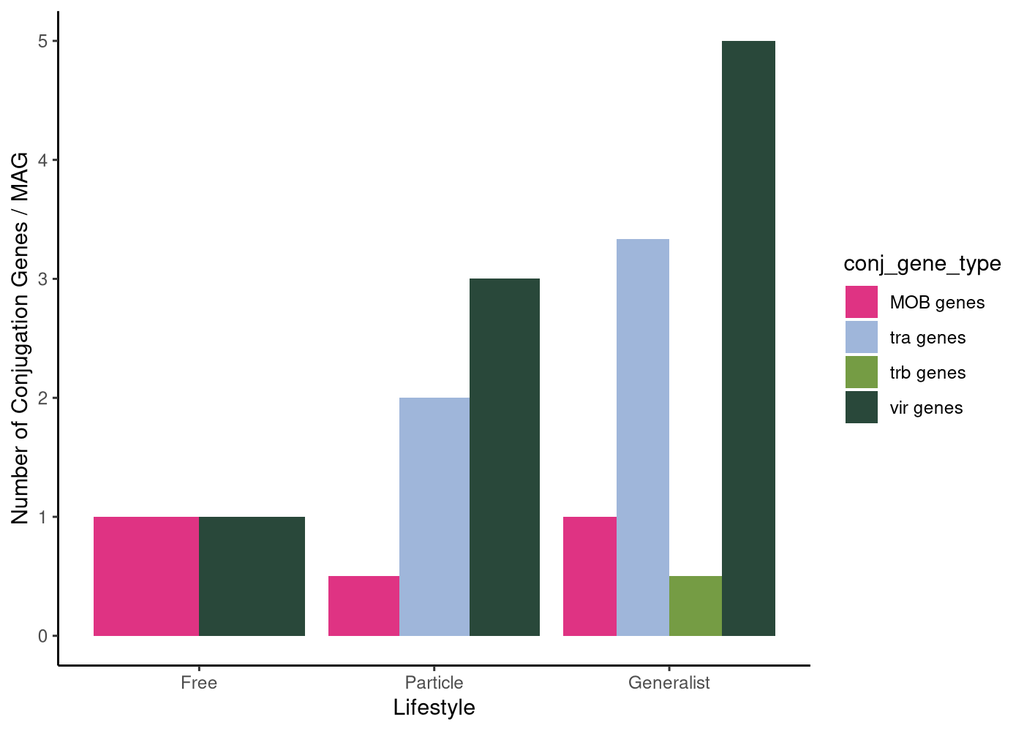

```r
#now we are going to divide by the conjugation gene type by the bin
count_seq_name$genes_per_bin <- count_seq_name$Count_Genes / count_seq_name$Count_Seq_name

#now that we have ourgenes/sequence name we can plot our data to see what is happening
conj_genes_per_bin <- ggplot(count_seq_name, aes(x = fraction_class, y = genes_per_bin, fill = conj_gene_type))+
  geom_bar(stat = "identity", position = "dodge") +
  #ggtitle("fraction class ~ genes/bin")+
  #scale_fill_carto_d(palette = "Geyser")+
  xlab("Lifestyle")+
  ylab("Number of Conjugation Genes / MAG")+
  scale_fill_wa_d(palette = "rainier", reverse = TRUE)+
  #scale_fill_brewer(palette = "Dark2")
  theme_classic()
  #theme(plot.title = element_text(hjust = 0.5))
conj_genes_per_bin
```

### Phage Analysis

#### Number of phage encoded genes per MAG

```r
#now lets divide the number of genes by MAG (AKA lest visualize the number of plasmid encoded genes per bin)

#count all the genes in the bin
phab_genes <- merge_virussum_magfull
total_phab_genes_bin <- phab_genes %>%
  group_by(Seq_Name, Bin, n_genes, fraction_class) %>%
  summarise(
    Count_Genes = n(),
    .groups = "drop",
    total_n_genes = sum(n_genes))


#now count the number of seq_names
count_phab_seq <- total_phab_genes_bin %>%
  group_by(Seq_Name) %>%
  mutate(Count_Seq_name = n())

count_phab_seq
```

```
## # A tibble: 1,306 × 7
## # Groups:   Seq_Name [278]
##    Seq_Name             Bin    n_genes fraction_class Count_Genes total_n_genes Count_Seq_name
##    <chr>                <chr>    <int> <fct>                <int>         <int>          <int>
##  1 91614_DAStool_bin11  bin11        2 Generalist               1             2              2
##  2 91614_DAStool_bin11  bin11        7 Generalist               1             7              2
##  3 91614_DAStool_bin128 bin128       1 Generalist               1             1              3
##  4 91614_DAStool_bin128 bin128       5 Generalist               1             5              3
##  5 91614_DAStool_bin128 bin128       6 Generalist               1             6              3
##  6 91614_DAStool_bin135 bin135       2 Generalist               1             2              1
##  7 91614_DAStool_bin138 bin138       3 Generalist               1             3              1
##  8 91614_DAStool_bin140 bin140       1 Generalist               1             1              5
##  9 91614_DAStool_bin140 bin140       2 Generalist               2             4              5
## 10 91614_DAStool_bin140 bin140       5 Generalist               1             5              5
## # ℹ 1,296 more rows
```

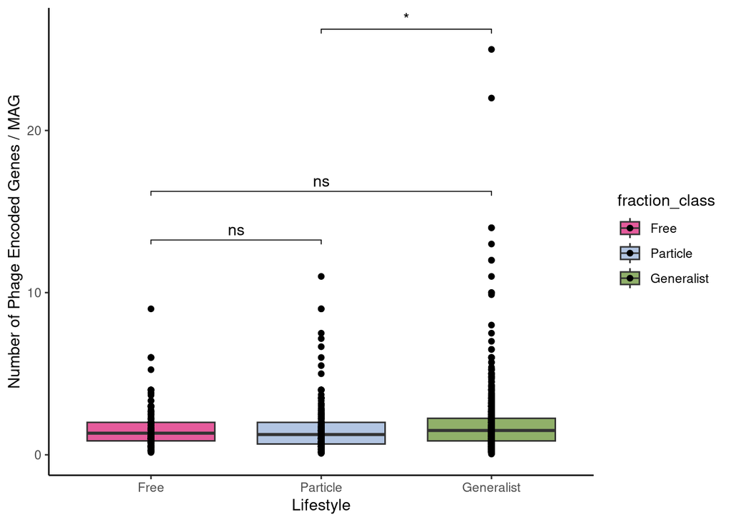

```r
#now we are going to divide by the # gene type by the bin
count_phab_seq$genes_per_bin <- count_phab_seq$total_n_genes / count_phab_seq$Count_Seq_name

#now that we have ourgenes/sequence name we can plot our data to see what is happening
phab_gene_per_bin <- ggplot(count_phab_seq, aes(x = fraction_class, y = genes_per_bin, fill = fraction_class))+
  geom_boxplot(outlier.shape = NA, alpha = .8)+
  geom_point()+
  #ggtitle("fraction class ~ genes/bin")+
  #scale_fill_carto_d(palette = "Geyser")+
  xlab("Lifestyle")+
  ylab("Number of Phage Encoded Genes / MAG")+
  scale_fill_wa_d(palette = "rainier", reverse = TRUE)+
  #scale_fill_brewer(palette = "Dark2")
  #coord_cartesian(ylim = quantile(count_peg_seq$genes_per_bin, c(0.0001,0.9999)))+
  stat_compare_means(label.y = c(12,15,25), tip.length = .01, comparisons = list(
    c("Free", "Particle"),
    c("Free", "Generalist"),
    c("Particle", "Generalist")),
                 method = "wilcox.test", paired = FALSE,
                 label = "p.signif", hide.ns = FALSE)+

  #do p adjust for stat compare means and fdr
  theme_classic()
phab_gene_per_bin
```

#### Bar graph visualizing the number of phage genes and phage taxonomy

```r
#we will delmit so that we can see what phages are present in our dataset
#create different variable of the df so that in case we mess up its gonna be ok
tax_phass <- merge_virussum_magfull

#split the column called taxonomy.filename into multiple columns by the delimiter ";"
tax_phass <- tax_phass %>% separate(taxonomy.filename, c('Vir_Domain', "Realm", "Kingdom", "Phylum_vir", "Class_cvir", "Order_vir", "Species_vir"))


#lets use rbind to combine tax_phass and count_phab_seq

phab_tax_phass_combine <- merge(tax_phass, count_phab_seq)

#now we can visualize the number of phage genes and look at the phage taxonomy
number_of_phage_genes <- ggplot(phab_tax_phass_combine, aes(x = fraction_class, y = genes_per_bin, fill = Phylum_vir))+
  geom_bar(position = "dodge", stat = "identity") +
  scale_fill_carto_d(palette = "Geyser")+
  xlab("Lifestyle")+
  ylab("Number of Phage Genes Encoded / MAG")+
  theme_classic()

number_of_phage_genes
```

[output not shown]

#### Density plot of phage encoded genes per MAG

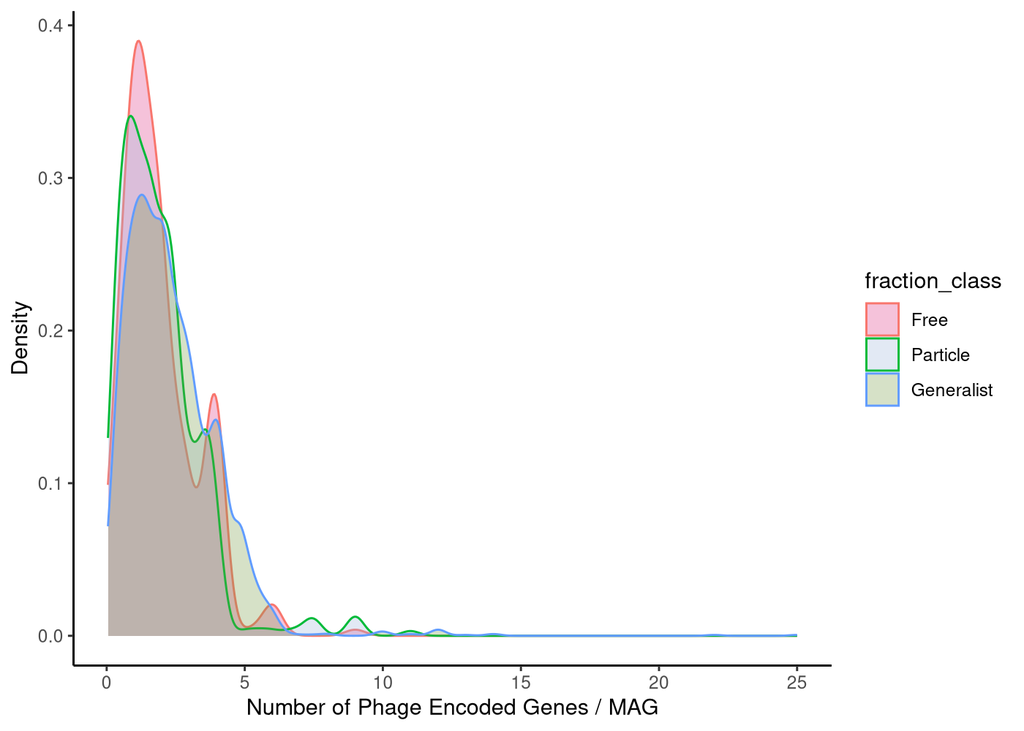

```r
phage_encoded_density <- ggplot(phab_tax_phass_combine, aes(x = genes_per_bin, color = fraction_class, fill = fraction_class))+
  geom_density(alpha = 0.3)+
  xlab("Number of Phage Encoded Genes / MAG")+
  ylab("Density")+
  scale_fill_wa_d(palette = "rainier", reverse = TRUE)+
  theme_classic()

phage_encoded_density
```

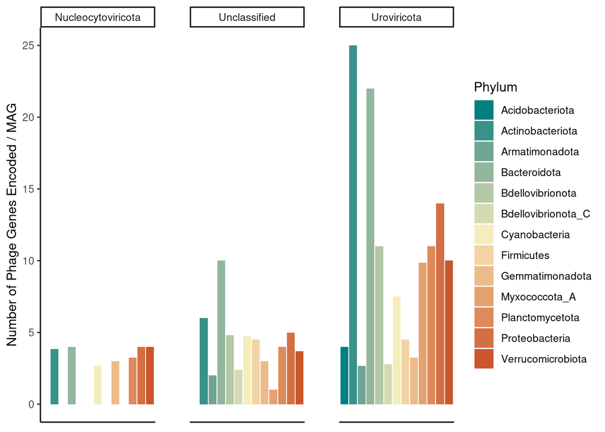

```r
#changing in the phylum_vir column the names "NA" to unclassified
phab_tax_phass_combine$Phylum_vir[is.na(phab_tax_phass_combine$Phylum_vir)] <- "Unclassified"

#now plotting using a facet to see from the most common phages and where they are present in bacterial phyla
#ommitted phages that were present in only one bacterial phylum
number_of_phage_genes1 <-
  phab_tax_phass_combine %>%
  dplyr::filter(Phylum_vir %in% c("Uroviricota", "Nucleocytoviricota", "Unclassified")) %>%
  ggplot(aes(x = Phylum, y = genes_per_bin, fill = Phylum))+
  facet_wrap(~ Phylum_vir) +
  geom_bar(position = "dodge", stat = "identity") +
 theme_classic() +
   theme(
    axis.title.x = element_blank(),
    #axis.text.x = element_text(angle = 30, vjust = 1, hjust = 1),
    axis.text.x = element_blank(),
    axis.ticks.x = element_blank(),
    panel.spacing = unit(2, "lines")
    )+
  scale_fill_carto_d(palette = "Geyser")+
  labs(x = "Lifestyle",
       y = "Number of Phage Genes Encoded / MAG");number_of_phage_genes1
```

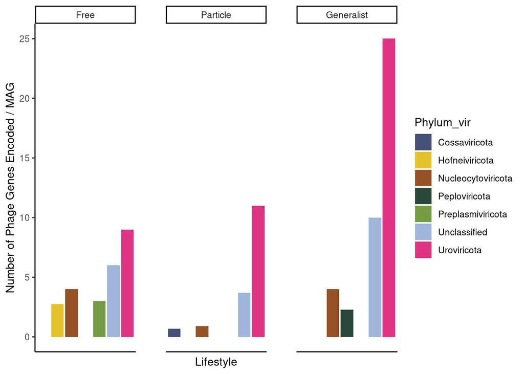

```r
 #now looking at lifestyle as opposed to bacterial phylum
number_of_phage_genes2 <-
  phab_tax_phass_combine %>%
  #dplyr::filter(Phylum_vir %in% c("Uroviricota", "Nucleocytoviricota", "Unclassified")) %>%
  ggplot(aes(x = Phylum_vir, y = genes_per_bin, fill = Phylum_vir))+
  facet_wrap(~ fraction_class) +
  geom_bar(position = "dodge", stat = "identity") +
 theme_classic() +
   theme(
    #axis.title.x = element_blank(),
    #axis.text.x = element_text(angle = 30, vjust = 1, hjust = 1),
    axis.text.x = element_blank(),
    axis.ticks.x = element_blank(),
    panel.spacing = unit(2, "lines")
    )+
  scale_fill_wa_d(palette = "rainier", reverse = FALSE)+
  #scale_fill_carto_d(palette = "Geyser")+
  labs(x = "Lifestyle",
       y = "Number of Phage Genes Encoded / MAG");number_of_phage_genes2
```

# Introduction

Analyzing metagenomic data from Muskegon Lake collected from 2014-2015. The primary goal is to identify whether there is a difference in phage communities between particle-associated (PA) and free-living (FL) bacteria. We will be using bioinformatic tools such as geNomad to analyze phages in samples.

## Phage Rotation Project

### Date: 2023_09_05

Objective: Install geNomad and download the database

Purpose: geNomad will be used to identify viruses and plasmids in sequencing data. Has additional features like taxonomic assignment of viral genomes, identifying proviruses, and functional annonation of proteins.

Protocol: 1. install geNomad - so far conda and pipx were unsuccessful for me to install - I was able to successfully install with docker

2. Downloading the database
- geNomad depends on a database that contains profile markers to classify sequences, taxonomic info, functional annonations, etc.
- this was done on docker and I did not need to download the database it already did it for me when I installed it first
3. Get access to bioHPC server
- registered for account

Future goals: - use the practice FASTA file given on the geNomad website and follow the example - learn how to execute the command - learn how to understand the genomad_output directory

### Date: 2023_09_12

Objective: Create directory on the server (in local workdir). Explore other options than geNomad. Read papers about geNomad, MAG workflow,

Purpose: geNomad will be used to identify viruses and plasmids in sequencing data. Has additional features like taxonomic assignment of viral genomes, identifying proviruses, and functional annonation of proteins. The data will be downloaded from the server. Its good to see if there is anything better than geNomad. It is critical to understand how the MAG workflow is done to understand how the data is generated and to understand what data are in the files.

Protocol: 1. create diretory on bioHPC server - successfully created - successfully cloned my github

2. Exploring other options to geNomad
- I peronally feel that geNomad is the best option due to its ability to annontate from MAGs, predict MGEs like plasmids, and identify proviruses.
- Libusha Kelly has a preprint to annontate viral phage proteins but it takes it a step further IMO
- BV-BRC does not seem to make annonation with MAGs super easy but I have only had experience with it annonating for one single isolate
- tldr: I am still convinced that geNomad will be the best tool to use!
3. Read geNomad preprint
4. Read MAG assembly and workflow paper Marian sent

Future goals: - use the practice FASTA file given on the geNomad website and follow the example - learn how to execute the command - learn how to understand the genomad_output directory - keep reading the papers

### Date: 2023_10_04

#### Purpose

Today I will be continuing with organizing my geNomad output files. I am currently working on organizing my 4 concatenated files

I am also understanding each of the outputs from geNomad in each of the columns

#### Protocol

1. Working on my script in Rstudio called “organize_concatenated_outputs.R”
- This script is meant to delimit and organize the outputs of the columns
2. Understand the outputs of each column
- Reading their published paper and documentation from their website

#### Understanding geNomad output columns